# My R-markdown

2025-11-12

# Introduction to R Markdown

R Markdown is a simple file format. It lets you write regular text, embed R code, and see the code’s results all in one document. It’s a tool for making reproducible reports.

# Narrative and Analysis

In this report, we will look at the SP500 dataset from the Ecdat package. This dataset contains daily returns for the S&P 500. We will load the data, run a quick summary, and then plot the distribution of returns to understand its basic properties.

## Using LaTeX for Math

R Markdown also lets you write math formulas using LaTeX. You can write simple math inline, like $\alpha + \beta$, by wrapping it in single dollar signs.For larger equations, you can put them on their own line like the formula for a simple linear regression:

$$Y = \beta_0 + \beta_1 X + \epsilon$$

## R Code Chunk 1: Load Data and Summary

This first code chunk loads the Ecdat library and the SP500 dataset. It then runs a summary() function on the daily returns column.

```r
# Load the library and dataset
library(Ecdat)
data("SP500", package = "Ecdat")
sp_df <- as.data.frame(SP500)

# Run a simple analysis
summary(sp_df$r500)
```

```
##       Min.    1st Qu.     Median       Mean    3rd Qu.       Max.
## -0.2280063 -0.0048451  0.0005357  0.0004181  0.0057658  0.0870888
```

## R Code Chunk 2: Generate Plot

This second code chunk uses the loaded data to create a plot. A histogram is a good way to see the distribution of the S&P 500’s daily returns.

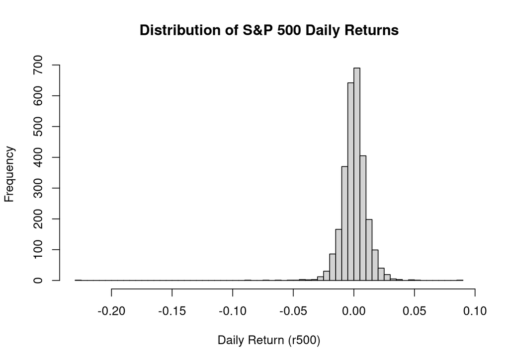

```r
# Generate a plot
hist(sp_df$r500,
     breaks = 100,
     main = "Distribution of S&P 500 Daily Returns",
     xlab = "Daily Return (r500)")
```